# Zestaw 1

Patrycja Piła

2022-10-11

## ZADANIE 1

Wprowadzam dwie zmienne

```r
pierwsza<- c(5,11,6,9,7,3,8,1)
druga<- c(9,15,7,6,3,5,8,2)
```

Wywołuje zmienne

```r
pierwsza
```

```
## [1]  5 11  6  9  7  3  8  1
```

```r
druga
```

```
## [1]  9 15  7  6  3  5  8  2
```

Wyznaczam zmienną suma, różnica i więcej

```r
suma <- pierwsza + druga
roznica <- pierwsza - druga
wiecej <- pierwsza + 1
```

Suma wynosi: 14, 26, 13, 15, 10, 8, 16, 3.

Różnica wynosi: -4, -4, -1, 3, 4, -2, 0, -1.

Więcej: 6, 12, 7, 10, 8, 4, 9, 2.

Średnia arytmetyczna wyznaczona za pomocą funkcji `mean()` oraz odchylenie standardowe wyznaczone za pomocą funkcji `sd()`

```r
mean(pierwsza)
```

```
## [1] 6.25
```

```r
mean(druga)
```

```
## [1] 6.875
```

```r
sd(pierwsza)
```

```
## [1] 3.24037
```

```r
sd(druga)
```

```
## [1] 4.051014
```

Średnia arytmetyczna pierwszego zestawu wynosi 6.25.

Odchylenie standardowe durgiego zestawu wynosi 4.051014.

## ZADANIE 2

Tworzę ramkę danych o nazwie osoby, która się składa z obserwacji ``wzrost` i `waga`

```r
osoby<- data.frame(

  "wzrost"=c(175,165,168,182,190,157,169),

  "waga"= c(75,58,72,76,85,55,62))
```

Wygląda ona w następujący sposób:

```r
osoby
```

```
##   wzrost waga
## 1    175   75
## 2    165   58
## 3    168   72
## 4    182   76
## 5    190   85
## 6    157   55
## 7    169   62
```

Sprawdzam strukturę obiektu za pomocą komendy `str()`

```r
str(osoby)
```

```
## 'data.frame':    7 obs. of  2 variables:
##  $ wzrost: num  175 165 168 182 190 157 169
##  $ waga  : num  75 58 72 76 85 55 62
```

Poznaję kilka pierwszych obiektów w zbiorze

```r
head(osoby)
```

```
##   wzrost waga
## 1    175   75
## 2    165   58
## 3    168   72
## 4    182   76
## 5    190   85
## 6    157   55
```

Poznaję kilka ostatnich obiektów w zbiorze

```r
tail(osoby)
```

```
##   wzrost waga
## 2    165   58
## 3    168   72
## 4    182   76
## 5    190   85
## 6    157   55
## 7    169   62
```

Poznaję rozmiar obiektu

```r
dim(osoby)
```

```
## [1] 7 2
```

Wyznaczam podstawowe statystyki opisowe w obiekcie

```r
summary(osoby)
```

```
##      wzrost           waga
##  Min.   :157.0   Min.   :55.0
##  1st Qu.:166.5   1st Qu.:60.0
##  Median :169.0   Median :72.0
##  Mean   :172.3   Mean   :69.0
##  3rd Qu.:178.5   3rd Qu.:75.5
##  Max.   :190.0   Max.   :85.0
```

## ZADANIE 3

Nadaję imiona obiektom z ramki osoby dzięki komendzie `rownames()` i ją wyświetlam

```r
rownames(osoby)<-c("Weronika","Alicja","Magda","Adam","Daniel","Ola","Klaudia")

osoby
```

```
##          wzrost waga
## Weronika    175   75
## Alicja      165   58
## Magda       168   72
## Adam        182   76
## Daniel      190   85
## Ola         157   55
## Klaudia     169   62
```

Następnie tworzę obiekt `BMI`

```r
wzrost<-c(175,165,168,182,190,157,169)

waga<- c(75,58,72,76,85,55,62)

BMI<- waga/(wzrost/100)^2
```

Wyświetlam tylko te osoby, których wartość BMI wynosi więcej niż 30. Na początek dodaję obiekt `BMI` do ramki `osoby`

```r
osoby['BMI']<-BMI
osoby[BMI > 30]
```

```
## ramka danych z zerową liczbą kolumn oraz 7 wierszami
```

Aby zliczyć ile osób ma **BMI<= 25** posługuję się komendą `sum()`

```r
sum(BMI<=25)
```

```
## [1] 6
```

## ZADANIE 4

Robię analizę ramek danych `mtcars` i `Orange`

1. Komenda `str()` pozwala na sprawdzenie jakiego typu są zmienne.

```r
str(mtcars)
```

```
## 'data.frame':    32 obs. of  11 variables:
##  $ mpg : num  21 21 22.8 21.4 18.7 18.1 14.3 24.4 22.8 19.2 ...
##  $ cyl : num  6 6 4 6 8 6 8 4 4 6 ...
##  $ disp: num  160 160 108 258 360 ...
##  $ hp  : num  110 110 93 110 175 105 245 62 95 123 ...
##  $ drat: num  3.9 3.9 3.85 3.08 3.15 2.76 3.21 3.69 3.92 3.92 ...
##  $ wt  : num  2.62 2.88 2.32 3.21 3.44 ...
##  $ qsec: num  16.5 17 18.6 19.4 17 ...
##  $ vs  : num  0 0 1 1 0 1 0 1 1 1 ...
##  $ am  : num  1 1 1 0 0 0 0 0 0 0 ...
##  $ gear: num  4 4 4 3 3 3 3 4 4 4 ...
##  $ carb: num  4 4 1 1 2 1 4 2 2 4 ...
```

```r
str(Orange)
```

```
## Classes 'nfnGroupedData', 'nfGroupedData', 'groupedData' and 'data.frame':   35 obs. of  3 variables:
##  $ Tree         : Ord.factor w/ 5 levels "3"<"1"<"5"<"2"<..: 2 2 2 2 2 2 2 4 4 4 ...
##  $ age          : num  118 484 664 1004 1231 ...
##  $ circumference: num  30 58 87 115 120 142 145 33 69 111 ...
##  - attr(*, "formula")=Class 'formula'  language circumference ~ age | Tree
##   .. ..- attr(*, ".Environment")=<environment: R_EmptyEnv>
##  - attr(*, "labels")=List of 2
##   ..$ x: chr "Time since December 31, 1968"
##   ..$ y: chr "Trunk circumference"
##  - attr(*, "units")=List of 2
##   ..$ x: chr "(days)"
##   ..$ y: chr "(mm)"
```

Jak widać w przypadku `mtcars` wszystkie zmienne są numeryczne, a w ramce danych `Orange` wsytępują różne typy danych

2. Komenda `help()` wyświetla informacje na temat danej ramki danych, m.in. jak jej używać, jaki jest format oraz źródło

```r
help(mtcars)
```

```
## uruchamianie serwera httpd dla pomocy ... wykonano
```

```r
help(Orange)
```

- Wyświetlam wylącznie auta posiadające 6 cylindrów

```r
mtcars[mtcars$cyl == 6,]
```

```
##                 mpg cyl  disp  hp drat    wt  qsec vs am gear carb
## Mazda RX4      21.0   6 160.0 110 3.90 2.620 16.46  0  1    4    4
## Mazda RX4 Wag  21.0   6 160.0 110 3.90 2.875 17.02  0  1    4    4
## Hornet 4 Drive 21.4   6 258.0 110 3.08 3.215 19.44  1  0    3    1
## Valiant        18.1   6 225.0 105 2.76 3.460 20.22  1  0    3    1
## Merc 280       19.2   6 167.6 123 3.92 3.440 18.30  1  0    4    4
## Merc 280C      17.8   6 167.6 123 3.92 3.440 18.90  1  0    4    4
## Ferrari Dino   19.7   6 145.0 175 3.62 2.770 15.50  0  1    5    6
```

- Tworzę histogram dla wybranej zmiennej z ramki `Orange`

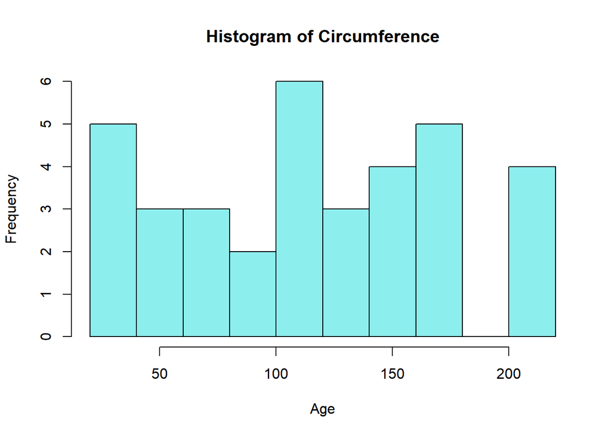

```r
hist(Orange$circumference, col="darkslategray2", main = 'Histogram of Circumference', xlab='Age')
```

- Rysuję wykres pudełkowy z wąsem `(boxplot())` dla zmiennych `mpg`, `hp` i `qsec` ze zbioru mtcars

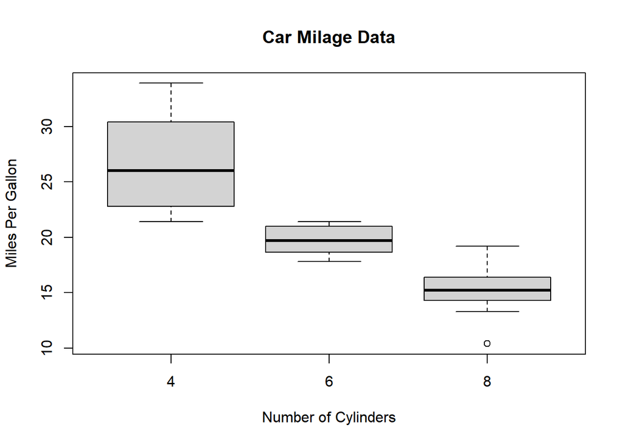

```r
boxplot(mpg~cyl,data=mtcars, main="Car Milage Data",
        xlab="Number of Cylinders", ylab="Miles Per Gallon")
```

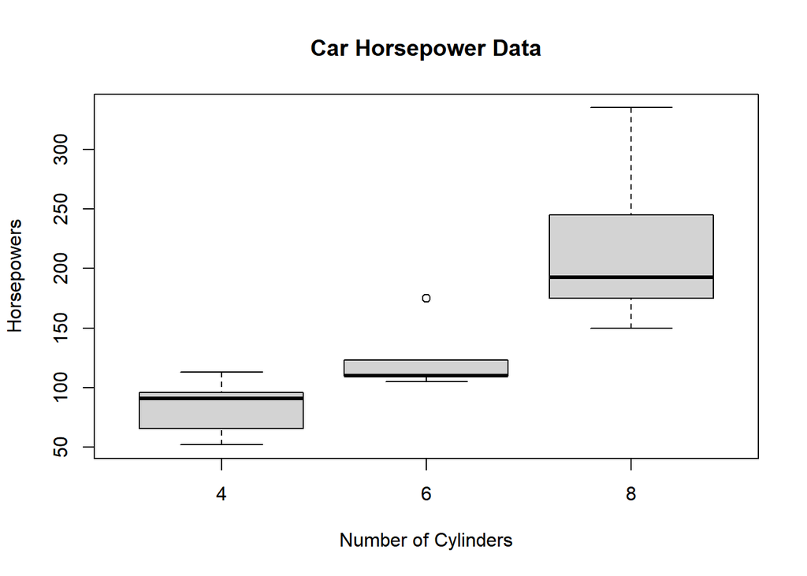

```r
boxplot(hp~cyl,data=mtcars, main="Car Horsepower Data",
        xlab="Number of Cylinders", ylab="Horsepowers")
```

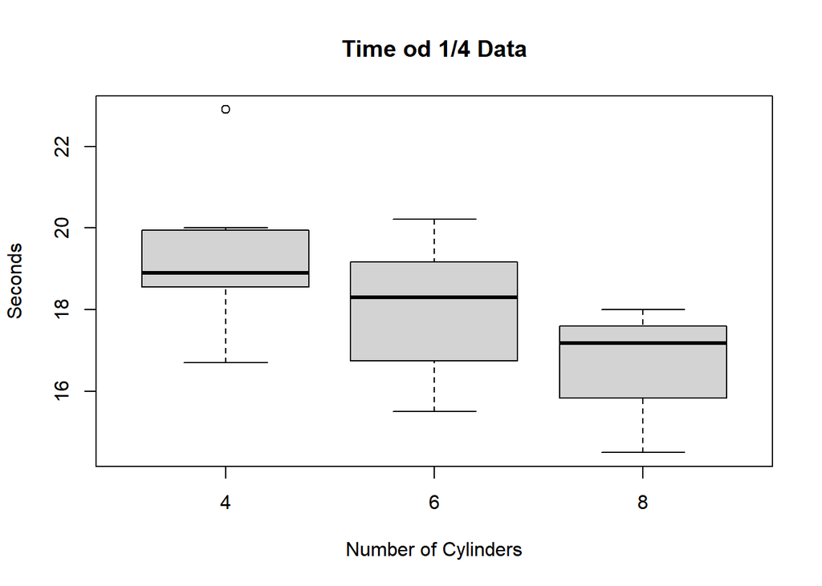

```r
boxplot(qsec~cyl,data=mtcars, main="Time od 1/4 Data",
        xlab="Number of Cylinders", ylab="Seconds")
```

## ZADANIE 5

Instaluję pakiet, który jest przydatnym narzędziem statystycznym dla psychologów o nazwie `psych`

```r
library(psych)
```

Korzystam z funkcji describe()

```r
describe(mtcars)
```

```
##      vars  n   mean     sd median trimmed    mad   min    max  range  skew
## mpg     1 32  20.09   6.03  19.20   19.70   5.41 10.40  33.90  23.50  0.61
## cyl     2 32   6.19   1.79   6.00    6.23   2.97  4.00   8.00   4.00 -0.17
## disp    3 32 230.72 123.94 196.30  222.52 140.48 71.10 472.00 400.90  0.38
## hp      4 32 146.69  68.56 123.00  141.19  77.10 52.00 335.00 283.00  0.73
## drat    5 32   3.60   0.53   3.70    3.58   0.70  2.76   4.93   2.17  0.27
## wt      6 32   3.22   0.98   3.33    3.15   0.77  1.51   5.42   3.91  0.42
## qsec    7 32  17.85   1.79  17.71   17.83   1.42 14.50  22.90   8.40  0.37
## vs      8 32   0.44   0.50   0.00    0.42   0.00  0.00   1.00   1.00  0.24
## am      9 32   0.41   0.50   0.00    0.38   0.00  0.00   1.00   1.00  0.36
## gear   10 32   3.69   0.74   4.00    3.62   1.48  3.00   5.00   2.00  0.53
## carb   11 32   2.81   1.62   2.00    2.65   1.48  1.00   8.00   7.00  1.05
##      kurtosis    se
## mpg     -0.37  1.07
## cyl     -1.76  0.32
## disp    -1.21 21.91
## hp      -0.14 12.12
## drat    -0.71  0.09
## wt      -0.02  0.17
## qsec     0.34  0.32
## vs      -2.00  0.09
## am      -1.92  0.09
## gear    -1.07  0.13
## carb     1.26  0.29
```

```r
summary(mtcars)
```

```
##       mpg             cyl             disp             hp
##  Min.   :10.40   Min.   :4.000   Min.   : 71.1   Min.   : 52.0
##  1st Qu.:15.43   1st Qu.:4.000   1st Qu.:120.8   1st Qu.: 96.5
##  Median :19.20   Median :6.000   Median :196.3   Median :123.0
##  Mean   :20.09   Mean   :6.188   Mean   :230.7   Mean   :146.7
##  3rd Qu.:22.80   3rd Qu.:8.000   3rd Qu.:326.0   3rd Qu.:180.0
##  Max.   :33.90   Max.   :8.000   Max.   :472.0   Max.   :335.0
##       drat             wt             qsec             vs
##  Min.   :2.760   Min.   :1.513   Min.   :14.50   Min.   :0.0000
##  1st Qu.:3.080   1st Qu.:2.581   1st Qu.:16.89   1st Qu.:0.0000
##  Median :3.695   Median :3.325   Median :17.71   Median :0.0000
##  Mean   :3.597   Mean   :3.217   Mean   :17.85   Mean   :0.4375
##  3rd Qu.:3.920   3rd Qu.:3.610   3rd Qu.:18.90   3rd Qu.:1.0000
##  Max.   :4.930   Max.   :5.424   Max.   :22.90   Max.   :1.0000
##        am              gear            carb
##  Min.   :0.0000   Min.   :3.000   Min.   :1.000
##  1st Qu.:0.0000   1st Qu.:3.000   1st Qu.:2.000
##  Median :0.0000   Median :4.000   Median :2.000
##  Mean   :0.4062   Mean   :3.688   Mean   :2.812
##  3rd Qu.:1.0000   3rd Qu.:4.000   3rd Qu.:4.000
##  Max.   :1.0000   Max.   :5.000   Max.   :8.000
```

- Czym różni się funkcja `describe()` od funkcji `summary()`?

Obie funkcje obliczają podstawowe statysyki, przy czym sposób ich wyśiwtlenia jest inny. Używając funkcji describe łatwiej porównać dane, funkcja summary przedstawia dane dla każdej wartości z osobna.

- Wykorzystuję funkcję describeBy() grupując auta np. według liczby cylindrów

```r
describeBy(mtcars ~ cyl)
```

```
##
##  Descriptive statistics by group
## cyl: 4
##      vars  n   mean    sd median trimmed   mad   min    max range  skew
## mpg     1 11  26.66  4.51  26.00   26.44  6.52 21.40  33.90 12.50  0.26
## cyl     2 11   4.00  0.00   4.00    4.00  0.00  4.00   4.00  0.00   NaN
## disp    3 11 105.14 26.87 108.00  104.30 43.00 71.10 146.70 75.60  0.12
## hp      4 11  82.64 20.93  91.00   82.67 32.62 52.00 113.00 61.00  0.01
## drat    5 11   4.07  0.37   4.08    4.02  0.34  3.69   4.93  1.24  1.00
## wt      6 11   2.29  0.57   2.20    2.27  0.54  1.51   3.19  1.68  0.30
## qsec    7 11  19.14  1.68  18.90   18.99  1.48 16.70  22.90  6.20  0.55
## vs      8 11   0.91  0.30   1.00    1.00  0.00  0.00   1.00  1.00 -2.47
## am      9 11   0.73  0.47   1.00    0.78  0.00  0.00   1.00  1.00 -0.88
## gear   10 11   4.09  0.54   4.00    4.11  0.00  3.00   5.00  2.00  0.11
## carb   11 11   1.55  0.52   2.00    1.56  0.00  1.00   2.00  1.00 -0.16
##      kurtosis   se
## mpg     -1.65 1.36
## cyl       NaN 0.00
## disp    -1.64 8.10
## hp      -1.71 6.31
## drat     0.12 0.11
## wt      -1.36 0.17
## qsec    -0.02 0.51
## vs       4.52 0.09
## am      -1.31 0.14
## gear    -0.01 0.16
## carb    -2.15 0.16
## ------------------------------------------------------------
## cyl: 6
##      vars n   mean    sd median trimmed   mad    min    max  range  skew
## mpg     1 7  19.74  1.45  19.70   19.74  1.93  17.80  21.40   3.60 -0.16
## cyl     2 7   6.00  0.00   6.00    6.00  0.00   6.00   6.00   0.00   NaN
## disp    3 7 183.31 41.56 167.60  183.31 11.27 145.00 258.00 113.00  0.80
## hp      4 7 122.29 24.26 110.00  122.29  7.41 105.00 175.00  70.00  1.36
## drat    5 7   3.59  0.48   3.90    3.59  0.03   2.76   3.92   1.16 -0.74
## wt      6 7   3.12  0.36   3.21    3.12  0.36   2.62   3.46   0.84 -0.22
## qsec    7 7  17.98  1.71  18.30   17.98  1.90  15.50  20.22   4.72 -0.12
## vs      8 7   0.57  0.53   1.00    0.57  0.00   0.00   1.00   1.00 -0.23
## am      9 7   0.43  0.53   0.00    0.43  0.00   0.00   1.00   1.00  0.23
## gear   10 7   3.86  0.69   4.00    3.86  0.00   3.00   5.00   2.00  0.11
```

[output cut: 24 more lines]

```
## am      9 14   0.14  0.36   0.00    0.08  0.00   0.00   1.00   1.00  1.83
## gear   10 14   3.29  0.73   3.00    3.17  0.00   3.00   5.00   2.00  1.83
## carb   11 14   3.50  1.56   3.50    3.25  0.74   2.00   8.00   6.00  1.48
##      kurtosis    se
## mpg     -0.57  0.68
## cyl       NaN  0.00
## disp    -1.26 18.11
## hp       0.09 13.62
## drat     1.08  0.10
## wt      -0.71  0.20
## qsec    -0.92  0.32
## vs        NaN  0.00
## am       1.45  0.10
## gear     1.45  0.19
## carb     2.24  0.42
```

## ZADANIE 6

3. Generuję 20 wyników rzutu kostką do gry i nazywam tą zmienną `próba`

```r
próba<- sample(1:6,20,T)
próba
```

```
##  [1] 5 3 3 5 3 6 5 6 3 1 5 5 3 1 1 5 3 5 2 5
```

Następnie obliczam odchylenie standardowe `sd()` oraz średnią `mean()`

```r
sd(próba)
```

```
## [1] 1.650359
```

```r
mean(próba)
```

```
## [1] 3.75
```

4. Generuje 100 wyników rzutu monetą. Nazywam tą zmienną `rzut` (jako `1` oznaczam orła, a jako `0` reszkę)

```r
rzut <- sample(0:1,100,T)
```

Następnie zliczam ile wypadło orłów

```r
sum(rzut == 1)
```

```
## [1] 54
```

5. Generuje 10 liczb ze zbioru liczb naturalnych, bez zwracania

```r
nat <- sample(0:100,10,F)
nat
```

```
##  [1] 75 63 36 83 55 41 35 26 51  5
```

6. Pozanję funkcje `rnorm()`, `rt()` oraz `rpois()` i testuję jedną z nich

```r
help(rnorm)
help(rt)
help("rpois")

rt(6, 2, 1:10)
```

```
## [1]  0.7172104  1.6803415  3.4035054  9.2094370 19.9524613  6.3256730
```

## ZADANIE 7

Tworzę zestaw danych `lista`

```r
lista <- list(palenie <- c(F,T,T,F,F,T,F),
              cyfry <- 0:9,
              macierz <- matrix(sample(1:5,16,replace = T),4,4),
              tekst <- c("Litwo", "ojczyzno", "moja", "ty", "jestes", "jak", "zdrowie"))
```

- Odwołuje się do obiektu `tekst`

```r
lista[[4]]
```

```
## [1] "Litwo"    "ojczyzno" "moja"     "ty"       "jestes"   "jak"      "zdrowie"
```

- Odwołuje się do trzeciego elementu wektora `cyfry`

```r
lista[[2]][3]
```

```
## [1] 2
```

```r
lista[[3]][,2]
```

```
## [1] 5 5 5 2
```

## ZADANIE 8

Sprawdzam czy liczba jest podzielna przez 4

**Sposób 1**

```r
x <- 13

if(x%%4 == 0){
  print("Liczba podzielna przez 4")
} else {print("Liczba niepodzielna przez 4")
    }
```

```
## [1] "Liczba niepodzielna przez 4"
```

**Sposób 2**

```r
liczba <- 12
ifelse(liczba %% 4 == 0,
       "Liczba podzielna przez 4",
       "Liczba niepodzielna przez 4")
```

```
## [1] "Liczba podzielna przez 4"
```

## ZADANIE 9

Tworzę zmienną książki mówiącą o tym, ile dana osoba przeczytała książek w ostatnim kwartale.

```r
ksiazki <- sample(0:4, size = 25, replace = TRUE)
```

- Średnia liczba przeczytanych książek

```r
mean(ksiazki)
```

```
## [1] 2.36
```

- Ilość osób, które przeczytały przynajmniej 3 książki

```r
sum(ksiazki>= 3)
```

```
## [1] 14
```

- Ilość osób, które nie przeczytały żadnej książki

```r
sum(ksiazki == 0)
```

```
## [1] 5
```

```r
ksiazki2 <- ksiazki
for(i in 1:length(ksiazki2)){
  if(ksiazki2[i] >= 1){
         print("Ta osoba czyta książki")
  } else {
        print("Ta osoba nie czyta książek")
  }
  }
```

```
## [1] "Ta osoba czyta książki"
## [1] "Ta osoba czyta książki"
## [1] "Ta osoba czyta książki"
## [1] "Ta osoba czyta książki"
## [1] "Ta osoba nie czyta książek"
## [1] "Ta osoba czyta książki"
## [1] "Ta osoba nie czyta książek"
## [1] "Ta osoba czyta książki"
## [1] "Ta osoba czyta książki"
## [1] "Ta osoba nie czyta książek"
## [1] "Ta osoba nie czyta książek"
## [1] "Ta osoba czyta książki"
## [1] "Ta osoba czyta książki"
## [1] "Ta osoba czyta książki"
## [1] "Ta osoba czyta książki"
## [1] "Ta osoba czyta książki"
## [1] "Ta osoba czyta książki"
## [1] "Ta osoba czyta książki"
## [1] "Ta osoba czyta książki"
## [1] "Ta osoba czyta książki"
## [1] "Ta osoba czyta książki"
## [1] "Ta osoba czyta książki"
## [1] "Ta osoba nie czyta książek"
## [1] "Ta osoba czyta książki"
## [1] "Ta osoba czyta książki"
```

```r
dzien <- "2022-10-16"

library(lubridate)
day <- ymd(dzien)

miesiac31 <- c("1", "3", "5", "7", "8", "10", "12")
miesiac30 <- c("4", "6", "9", "11")
miesiac28 <- c("2")


miesiac <- function(m,r){if(month(m)%in%miesiac31 == TRUE){
  print("Miesiąc ma 31 dni")
} else if(month(m)%in%miesiac30 == TRUE){
  print("Miesiąc ma 30 dni")
} else {
    if(month(m)%in%miesiac28 & r%%100==0 & r%%400==0){
      print("Miesiąc ma 29 dni")
    } else if (month(m)%in%miesiac28 & r%%100!=0 & r%%4==0){
        print("Miesiąc ma 29 dni")
    } else {
        print("Miesiąc ma 28 dni")
      }
}}

miesiac(3,2022)
```

```
## [1] "Miesiąc ma 31 dni"
```

```r
miesiac(2,2020)
```

```
## [1] "Miesiąc ma 29 dni"
```

```r
miesiac(2,1900)
```

```
## [1] "Miesiąc ma 28 dni"
```

## ZADANIE 10

Funkcja, która zamienia temperaturę w Celsjuszach na temperaturę w Kelwinach i Fahrenheita

- Funkcja zamieniająca z stopni Celsjusza na Kelwiny

```r
celsius_to_kelvin <- function(temp_C) {
  temp_K <- temp_C + 273.15
  return(temp_K)
}
```

7 stopni C to 280.15 stopni Kelwina.

- Funkcja zamieniająca z stopni Celsjusza na Fahrenheit’a

```r
celcius_to_fahrenheit <- function(tempC) {
  temp_F <- (9/5)* tempC + 32
  return(temp_F)
}
```

30 stopni C to 86 stopni Fahrenheita.

## ZADANIE 11

Tworzyę funkcję, która na podstawie długości boków trójkąta, wyznacza jego pole. Dbam o to, by funkcja wyświetliła komunikat, jeśli podane długości boków nie tworzą trójkąta.

```r
obliczanie_pola <- function(a,b,c){
  if(a+b >c && a+c >b && c+b >a){
    p <- 0.5*(a+b+c)
    pole <- sqrt(p*(p-a)*(p-b)*(p-c))
    return(pole)
  } else{
    print("To nie jest trójkąt")
  }
}

obliczanie_pola(1,4,3)
```

```
## [1] "To nie jest trójkąt"
```

```r
obliczanie_pola(5,4,3)
```

```
## [1] 6
```

## ZADANIE 12

Stworzyłam funkcję, która na podstawie długości boków trójkąta odpowiada na pytanie o to, czy trójkąt jest ostrokątny, prostokątny lub rozwartokątny.

```r
rodzaj_trojkata <- function(a,b,c){
  if(a+b >c && a+c >b && c+b >a){
  if(a<=b && b<=c){
    if(a^2+b^2<c^2){
      print("Jest to trójkąt rozwartokątny")
    } else if(a^2+b^2>c^2){
      print("Jest to trójkąt ostrokątny")
    } else{
      print("Jest to trójkąt prostokątny")
    }
  } else {
    print("Wprowadz boki od najkrótszego do najdłużeszgo")
  }
  }else{
    print("To nie jest trójkąt")}
}

rodzaj_trojkata(5,8,9)
```

```
## [1] "Jest to trójkąt ostrokątny"
```

```r
rodzaj_trojkata(9,8,5)
```

```
## [1] "Wprowadz boki od najkrótszego do najdłużeszgo"
```

```r
rodzaj_trojkata(2.5,6,6.5)
```

```
## [1] "Jest to trójkąt prostokątny"
```

```r
rodzaj_trojkata(sqrt(2),sqrt(3),sqrt(6))
```

```
## [1] "Jest to trójkąt rozwartokątny"
```

```r
rodzaj_trojkata(1,2,3)
```

```
## [1] "To nie jest trójkąt"
```